# Tarea 1 — Caja de herramientas de pronóstico

## 9.6 Coeficientes y supuestos de la regresión

La regresión se estima sobre $\ln Y_t = a + \theta t + \varepsilon_t$, así que la tabla, $R^2$, $\hat\sigma^2$, Durbin–Watson y residuos están en logaritmos.

```r
tab(tabla_coef(fit))
```

|  | Coeficiente | Estimación | EE ordinario | EE robusto | t robusto | p robusto | p ordinario |
| --- | --- | --- | --- | --- | --- | --- | --- |
|  | a | -0,6968 | 0,0360 | 0,0426 | -16,3663 | < 0,001 | < 0,001 |
| t | theta | 0,0428 | 0,0009 | 0,0010 | 42,9616 | < 0,001 | < 0,001 |

$R^2 =$ 0,9727, $\hat\sigma^2_{ln} =$ 0,0228 (entre $T - p =$ 70 grados de libertad), estadístico de Durbin–Watson de los residuos 1,6898 y 3 rezagos en el error estándar robusto. Los errores estándar robustos superan a los ordinarios en un 18,38 % ($a$) y un 16,25 % ($\theta$): una diferencia modesta, porque la autocorrelación de orden uno de los residuos en logaritmos es pequeña. Aun así la decisión se toma con el robusto, que también cubre la autocorrelación en el rezago estacional:

```r
t_a <- .t_coeficiente("a", p$tabla$estimacion[1], p$tabla$ee_robusto[1], p$gl, T_est)
pp(t_a, paste0("a = ", n4(p$tabla$estimacion[1]), " es el logaritmo del nivel en t = 0, es decir, un nivel de ", n4(p$coef_exp[[1]]),
               " dólares. Se distingue de cero, pero lo que importa es la tasa: el nivel inicial es solo el punto de partida de la curva."))
```

**Prueba t del coeficiente $a$ con error estándar robusto** (n = 72)

1. **Hipótesis.** $H_0:\ a = 0$; $H_1:\ a \neq 0$.
2. **Estadístico y distribución bajo $H_0$.** $t = \dfrac{\hat{a}}{\widehat{EE}_{HAC}(\hat{a})}\ \overset{H_0}{\approx}\ t_{T-p}$; grados de libertad: $70$.
3. **Región de rechazo al 5 %.** $|t| > t_{0{,}975;\,70} = 1,9944$.
4. **Valor observado.** estadístico observado = -16,3663; valor p < 0,001.
5. **Decisión.** Se rechaza $H_0$ (nivel de significancia del 5 %).
6. **Lectura.** a = -0,6968 es el logaritmo del nivel en t = 0, es decir, un nivel de 0,4982 dólares. Se distingue de cero, pero lo que importa es la tasa: el nivel inicial es solo el punto de partida de la curva.

```r
t_th <- .t_coeficiente(r"(\theta)", p$tabla$estimacion[2], p$tabla$ee_robusto[2], p$gl, T_est)
pp(t_th, paste0("theta = ", n4(p$tabla$estimacion[2]), " es la tasa de crecimiento continua por trimestre (", n2(100 * (p$coef_exp[[2]] - 1)),
                " % en tasa compuesta). Se rechaza con un estadístico de ", n2(t_th$estadistico), " que la ganancia por acción no tenga tendencia: ",
                "la tasa es distinta de cero con una evidencia abrumadora."))
```

**Prueba t del coeficiente $\theta$ con error estándar robusto** (n = 72)

1. **Hipótesis.** $H_0:\ \theta = 0$; $H_1:\ \theta \neq 0$.
2. **Estadístico y distribución bajo $H_0$.** $t = \dfrac{\hat{\theta}}{\widehat{EE}_{HAC}(\hat{\theta})}\ \overset{H_0}{\approx}\ t_{T-p}$; grados de libertad: $70$.
3. **Región de rechazo al 5 %.** $|t| > t_{0{,}975;\,70} = 1,9944$.
4. **Valor observado.** estadístico observado = 42,9616; valor p < 0,001.
5. **Decisión.** Se rechaza $H_0$ (nivel de significancia del 5 %).
6. **Lectura.** theta = 0,0428 es la tasa de crecimiento continua por trimestre (4,37 % en tasa compuesta). Se rechaza con un estadístico de 42,96 que la ganancia por acción no tenga tendencia: la tasa es distinta de cero con una evidencia abrumadora.

Los supuestos se revisan sobre los residuos en logaritmos. Como en las otras tendencias, la media cero es cierta por construcción; se comprueban la autocorrelación, la normalidad y la varianza constante.

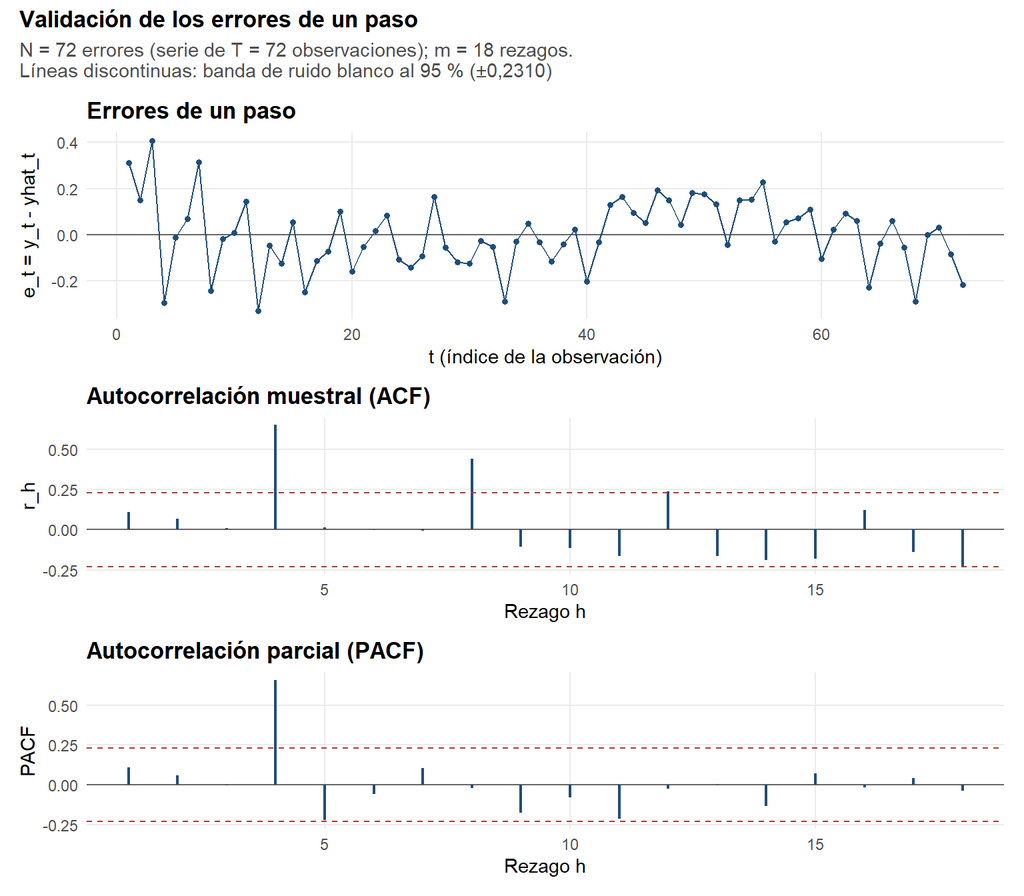

```r
ve_log <- validar_errores(p$residuos, fit$n_param, T_est, cot$dL, cot$dU)
ve_log$grafico
```

```r
pp(ve_log$ljung_box, paste0("Q = ", n4(ve_log$ljung_box$estadistico), " con ", ve_log$ljung_box$gl, " grados de libertad y valor p ",
                            pv(ve_log$ljung_box$valor_p), ": se rechaza. La autocorrelación no está en el rezago 1 (r_1 = ",
                            n4(ve_log$correlograma$acf[1]), ") sino en el estacional, r_", s, " = ", n4(ve_log$correlograma$acf[s]),
                            " y r_", 2 * s, " = ", n4(ve_log$correlograma$acf[2 * s]), ": los residuos repiten su patrón cada año."))
```

**Prueba de Ljung–Box sobre los errores** (n = 72)

1. **Hipótesis.** $H_0:\ \rho_1 = \rho_2 = \cdots = \rho_m = 0$; $H_1:\ \exists\, h \le m$ con $\rho_h \neq 0$.
2. **Estadístico y distribución bajo $H_0$.** $Q_m = T(T+2)\sum_{h=1}^{m} \dfrac{r_h^2}{T-h}\ \overset{H_0}{\sim}\ \chi^2_{m-p}$; $m = 18$, $p = 2$, luego los grados de libertad son $m - p = 16$.
3. **Región de rechazo al 5 %.** $Q_m > \chi^2_{0{,}95;\,16} = 26,2962$.
4. **Valor observado.** estadístico observado = 77,9700; valor p < 0,001.
5. **Decisión.** Se rechaza $H_0$ (nivel de significancia del 5 %).
6. **Lectura.** Q = 77,9700 con 16 grados de libertad y valor p < 0,001: se rechaza. La autocorrelación no está en el rezago 1 (r_1 = 0,1101) sino en el estacional, r_4 = 0,6549 y r_8 = 0,4417: los residuos repiten su patrón cada año.

```r
pp(ve_log$jarque_bera, paste0("JB = ", n4(ve_log$jarque_bera$estadistico), " con asimetría ", n4(ve_log$jarque_bera$A), " y curtosis ",
                              n4(ve_log$jarque_bera$K), ": los residuos en logaritmos son prácticamente normales. La log-transformación ",
                              "estabilizó los errores, lo que respalda usar la escala logarítmica."))
```

**Prueba de Jarque–Bera** (n = 72)

1. **Hipótesis.** $H_0:\ A = 0\ \text{y}\ K = 3$ (errores normales); $H_1:\ A \neq 0\ \text{o}\ K \neq 3$.
2. **Estadístico y distribución bajo $H_0$.** $JB = \dfrac{N}{6}\left[A^2 + \dfrac{(K-3)^2}{4}\right]\ \overset{H_0}{\sim}\ \chi^2_2$, con $A = m_3/m_2^{3/2}$ la asimetría y $K = m_4/m_2^2$ la curtosis muestrales; grados de libertad: $2$.
3. **Región de rechazo al 5 %.** $JB > \chi^2_{0{,}95;\,2} = 5,9915$.
4. **Valor observado.** estadístico observado = 0,0070; valor p = 0,997.
5. **Decisión.** No se rechaza $H_0$ (nivel de significancia del 5 %).
6. **Lectura.** JB = 0,0070 con asimetría 0,0219 y curtosis 3,0201: los residuos en logaritmos son prácticamente normales. La log-transformación estabilizó los errores, lo que respalda usar la escala logarítmica.

```r
pp(ve_log$durbin_watson, paste0("d = ", n4(ve_log$durbin_watson$estadistico), " supera d_U = ", n2(cot$dU), " (N = ", ve_log$n,
                                ", k' = 1): no se rechaza la ausencia de autocorrelación positiva de orden uno en logaritmos. Confirma que el problema de la ",
                                "regresión no es la dependencia de un trimestre con el anterior, sino la estacional."))
```

**Prueba de Durbin–Watson** (n = 72)

1. **Hipótesis.** $H_0:\ \rho = 0$ (sin autocorrelación de orden 1); $H_1:\ \rho > 0$.
2. **Estadístico y distribución bajo $H_0$.** $d = \dfrac{\sum_{t=2}^{N}(e_t - e_{t-1})^2}{\sum_{t=1}^{N} e_t^2} \approx 2(1 - r_1)$; sin distribución exacta bajo $H_0$, se decide con las cotas $d_L$ y $d_U$.
3. **Región de rechazo al 5 %.** Se rechaza $H_0$ si $d < d_L = 1,5900$; no se rechaza si $d > d_U = 1,6500$; inconclusa si $d_L \le d \le d_U$.
4. **Valor observado.** estadístico observado = 1,6898; sin valor p exacto (se decide con las cotas tabuladas).
5. **Decisión.** No se rechaza $H_0$ (nivel de significancia del 5 %).
6. **Lectura.** d = 1,6898 supera d_U = 1,65 (N = 72, k’ = 1): no se rechaza la ausencia de autocorrelación positiva de orden uno en logaritmos. Confirma que el problema de la regresión no es la dependencia de un trimestre con el anterior, sino la estacional.

**Varianza constante.** Se revisa con el gráfico de residuos contra valores ajustados (en logaritmos).

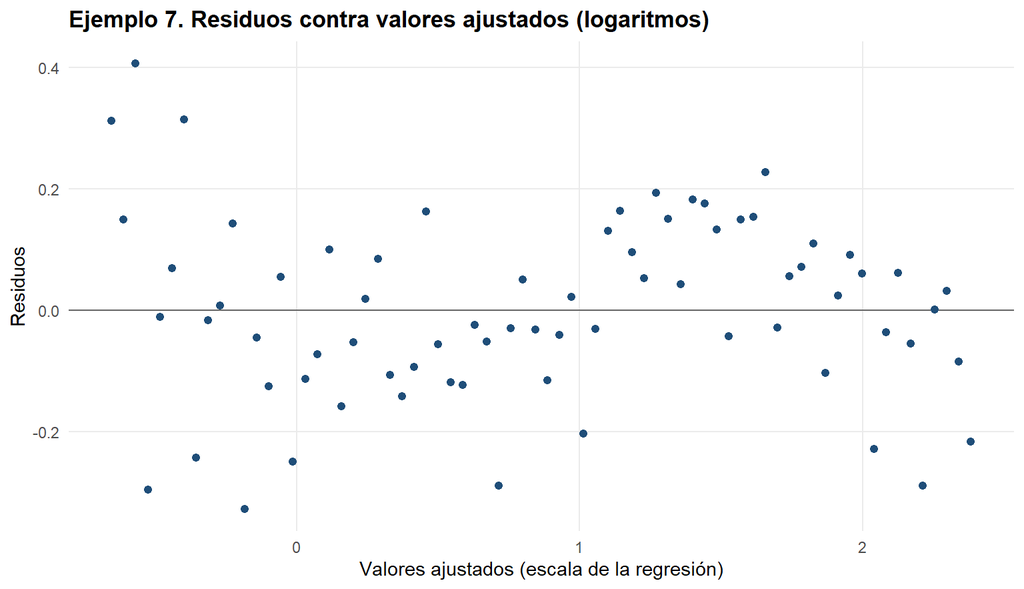

```r
.grafico_residuos_ajustados(log(est$y) - p$residuos, p$residuos, "Ejemplo 7. Residuos contra valores ajustados (logaritmos)")
```

La dispersión de los residuos en logaritmos es algo mayor al principio (desviación estándar de 0,17 en la primera mitad contra 0,13 en la segunda), pero no hay un abanico creciente: en logaritmos la varianza es aproximadamente constante, y esa es la ventaja de la escala logarítmica frente a la original, donde los errores crecen con el nivel.

**La estacionalidad, medida.** El efecto medio de cada trimestre sobre los residuos en logaritmos es:

```r
trimestre <- rep(seq_len(s), length.out = T_est)
efecto <- as.numeric(tapply(p$residuos, trimestre, mean))
tab(data.frame(Trimestre = paste0("T", seq_len(s)), `Efecto en logaritmos` = efecto,
               `Factor sobre la tendencia` = exp(efecto), check.names = FALSE))
```

| Trimestre | Efecto en logaritmos | Factor sobre la tendencia |
| --- | --- | --- |
| T1 | -0,0108 | 0,9893 |
| T2 | 0,0371 | 1,0378 |
| T3 | 0,1120 | 1,1186 |
| T4 | -0,1384 | 0,8708 |

El cuarto trimestre queda 12,92 % por debajo de la tendencia y el tercero 11,86 % por encima. La diferencia entre el mejor y el peor trimestre (0,2504 en logaritmos) equivale al 8,25 % del recorrido total de la tendencia en el tramo de estimación. Es pequeña frente a la tendencia y por eso el método sigue siendo útil, pero es lo que las pruebas de errores detectan y lo que limita el pronóstico.

## 9.7 Gráfico final

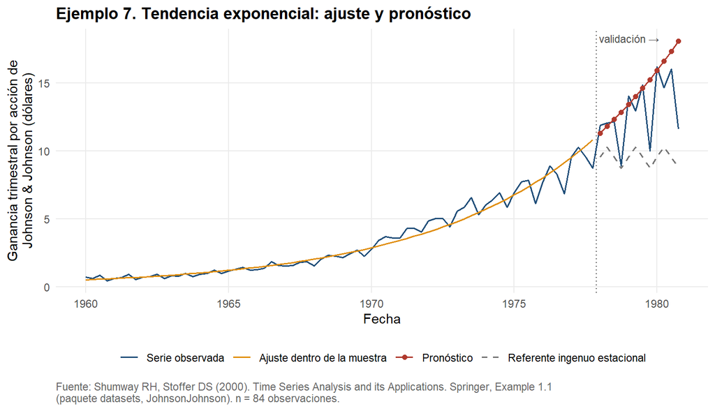

```r
.grafico_pronostico(d, fit$yhat, pron, ref, "Ejemplo 7. Tendencia exponencial: ajuste y pronóstico",
                    nombre_referente = "Referente ingenuo estacional")
```

## 9.8 Conclusión

Se ajustó una tendencia exponencial $\hat Y_t = 0,4982 \cdot 1,0437^{\,t}$ sobre los 72 trimestres de estimación, con un crecimiento de 4,37 % por trimestre ($t =$ 42,96 para $\theta$ con error estándar robusto, valor p < 0,001) y $R^2 =$ 0,9727 en logaritmos. Sobre los 12 trimestres de validación el MSE es 7,7384, el MAD 1,8450 y el MASE 3,5142, frente a 15,5810, 3,4275 y 6,5286 del ingenuo estacional: reduce el MSE en 50,33 %. La validación de errores muestra un método que capta la tendencia pero no la estacionalidad: Ljung–Box rechaza (valor p < 0,001) por el rezago estacional ($r_{4} =$ 0,7299), Durbin–Watson 1,2914 queda bajo $d_L =$ 1,59 y Jarque–Bera rechaza (valor p < 0,001) en la escala original, mientras que en logaritmos los residuos son normales (valor p 0,997) y sin autocorrelación de orden uno (Durbin–Watson 1,6898).

## 9.9 Recomendación

El pronóstico le sirve a quien siga el crecimiento de largo plazo de la ganancia por acción, por ejemplo un analista que quiera la trayectoria esperada del año siguiente, y no a quien necesite el valor de un trimestre concreto. El límite es la estacionalidad: en validación el método sobrestima el cuarto trimestre de forma sistemática: el pronóstico supera lo observado en 5,23 dólares en promedio en esos trimestres (errores absolutos de 3,94, 5,26, 6,49 en los tres años, 44,26 %, 52,67 %, 55,87 % del valor observado), frente a 0,72 dólares de error absoluto medio en los demás trimestres. Por eso el horizonte razonable es de un año para el nivel anual, con el pronóstico trimestral usado con reserva; para pronosticar cada trimestre haría falta un método que modele la estacionalidad (ficticias estacionales o Holt–Winters), que este trabajo no implementa.

# 10 Ejemplo 8. Holt sobre `austres`

Este ejemplo usa la misma serie del ejemplo 4, de modo que Holt y la doble media móvil se comparan sobre exactamente los mismos datos y el mismo tramo de validación.

## 10.1 Descripción de la serie

```r
x <- austres
d <- leer_serie(x,
                fuente = "Brockwell PJ, Davis RA (1996). Introduction to Time Series and Forecasting. Springer (paquete datasets, austres)",
                unidad = "Residentes de Australia (miles)")
descripcion(x, "austres", d)
```

| Campo | Valor |
| --- | --- |
| Nombre en R | austres |
| Fuente (help) | Brockwell PJ, Davis RA (1996). Introduction to Time Series and Forecasting. Springer (paquete datasets, austres) |
| Unidad | Residentes de Australia (miles) |
| Frecuencia | 4 |
| Inicio (año, período) | 1971, 2 |
| Fin (año, período) | 1993, 2 |
| Rango de fechas | 1971-04-01 a 1993-04-01 |
| Observaciones | 89 |

## 10.2 Patrón de la serie

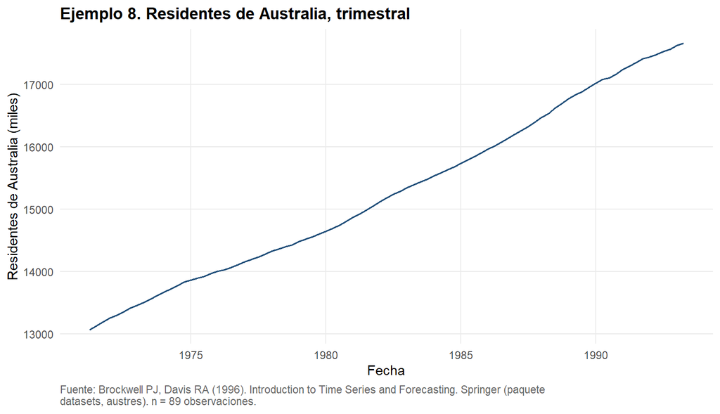

```r
graficar_serie(d, "Ejemplo 8. Residentes de Australia, trimestral")
```

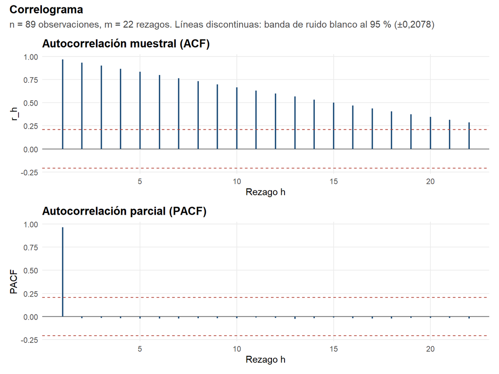

```r
cg <- correlograma(d)
cg$grafico
```

```r
n_total <- nrow(d)
r_1 <- .contraste_rh(cg$acf, n_total, 1)
pp(r_1, paste0("r_1 = ", n4(cg$acf[1]), " frente a una banda de ±", n4(cg$banda), ": cada trimestre repite casi entero al anterior. ",
               "Es la autocorrelación de una serie que crece y no de una que oscila alrededor de un nivel."))
```

**Contraste individual de la autocorrelación en el rezago h = 1** (n = 89)

1. **Hipótesis.** $H_0:\ \rho_{1} = 0$; $H_1:\ \rho_{1} \neq 0$.
2. **Estadístico y distribución bajo $H_0$.** $T^* = \dfrac{r_h}{\sqrt{1/n}} = \sqrt{n}\, r_h\ \overset{H_0}{\approx}\ N(0,1)$.
3. **Región de rechazo al 5 %.** $|T^*| > z_{0{,}975} = 1,9600$, es decir $|r_{1}| > 0,2078$.
4. **Valor observado.** estadístico observado = 9,1188; valor p < 0,001.
5. **Decisión.** Se rechaza $H_0$ (nivel de significancia del 5 %).
6. **Lectura.** r_1 = 0,9666 frente a una banda de ±0,2078: cada trimestre repite casi entero al anterior. Es la autocorrelación de una serie que crece y no de una que oscila alrededor de un nivel.

```r
r_8 <- .contraste_rh(cg$acf, n_total, 8)
pp(r_8, paste0("Aun en el rezago 8, dos años atrás, la autocorrelación es ", n4(cg$acf[8]), ", muy por encima de la banda de ±",
               n4(cg$banda), ". La ACF baja casi en línea recta y no se acerca a cero en ", cg$m, " rezagos: la serie no es estacionaria en media."))
```

**Contraste individual de la autocorrelación en el rezago h = 8** (n = 89)

1. **Hipótesis.** $H_0:\ \rho_{8} = 0$; $H_1:\ \rho_{8} \neq 0$.
2. **Estadístico y distribución bajo $H_0$.** $T^* = \dfrac{r_h}{\sqrt{1/n}} = \sqrt{n}\, r_h\ \overset{H_0}{\approx}\ N(0,1)$.
3. **Región de rechazo al 5 %.** $|T^*| > z_{0{,}975} = 1,9600$, es decir $|r_{8}| > 0,2078$.
4. **Valor observado.** estadístico observado = 6,9030; valor p < 0,001.
5. **Decisión.** Se rechaza $H_0$ (nivel de significancia del 5 %).
6. **Lectura.** Aun en el rezago 8, dos años atrás, la autocorrelación es 0,7317, muy por encima de la banda de ±0,2078. La ACF baja casi en línea recta y no se acerca a cero en 22 rezagos: la serie no es estacionaria en media.

```r
lb0 <- ljung_box(cg$acf, n_total, cg$m, 0)
pp(lb0, paste0("Q = ", n4(lb0$estadistico), " con ", lb0$gl, " grados de libertad y valor p ", pv(lb0$valor_p),
               ": rechazo contundente, la serie está lejos del ruido blanco."))
```

**Prueba de Ljung–Box** (n = 89)

1. **Hipótesis.** $H_0:\ \rho_1 = \rho_2 = \cdots = \rho_m = 0$; $H_1:\ \exists\, h \le m$ con $\rho_h \neq 0$.
2. **Estadístico y distribución bajo $H_0$.** $Q_m = T(T+2)\sum_{h=1}^{m} \dfrac{r_h^2}{T-h}\ \overset{H_0}{\sim}\ \chi^2_{m-p}$; $m = 22$, $p = 0$, luego los grados de libertad son $m - p = 22$.
3. **Región de rechazo al 5 %.** $Q_m > \chi^2_{0{,}95;\,22} = 33,9244$.
4. **Valor observado.** estadístico observado = 938,9522; valor p < 0,001.
5. **Decisión.** Se rechaza $H_0$ (nivel de significancia del 5 %).
6. **Lectura.** Q = 938,9522 con 22 grados de libertad y valor p < 0,001: rechazo contundente, la serie está lejos del ruido blanco.

**Lectura del patrón.** Es una tendencia creciente casi recta (una regresión sobre $t$ explica el 99,39 % de la variación), pero con una pendiente que se mueve. Promediando el crecimiento sobre ventanas de ocho trimestres, la pendiente local va de un mínimo de

```r
inc <- diff(d$y)                                                   # crecimiento trimestral
pend_local <- vapply(seq_len(length(inc) - 7), function(i) mean(inc[i:(i + 7)]), 0)
```

34,76 a un máximo de 71,78 miles de residentes por trimestre. Ese es el supuesto de Holt: una tendencia lineal *local*, con un nivel y una pendiente que se actualizan con cada dato. Una sola recta para toda la serie no puede seguir esa variación de la pendiente, y por eso aquí se usa un método que la reestima.

## 10.3 Partición

```r
h <- min(12, floor(0.2 * n_total)); T_est <- n_total - h
est <- d[seq_len(T_est), ]; val <- d[T_est + seq_len(h), ]
```

Con $T = 89$ y $h = 12$ (tres años), el tramo de estimación va de 1971-04-01 a 1990-04-01 ($T_{est} = 77$) y el de validación de 1990-07-01 a 1993-04-01.

## 10.4 Optimización de las constantes

El par $(\alpha, \beta)$ se elige con `optimizar()` sobre una rejilla que combina todos los valores de $\alpha$ con todos los de $\beta$, minimizando el MSE de un paso dentro del tramo de estimación (origen común en $t = 2$).

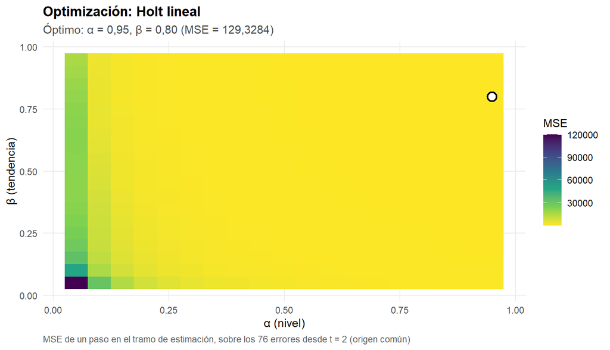

```r
opt <- optimizar(est$y, "holt")
n_alpha <- length(unique(opt$rejilla$alpha)); n_beta <- length(unique(opt$rejilla$beta))
paso_grilla <- diff(sort(unique(opt$rejilla$alpha)))[1]
opt$grafico
```

```r
tab(head(opt$rejilla[order(opt$rejilla$mse), ], 6), 2)
```

| alpha | beta | mse |
| --- | --- | --- |
| 0,95 | 0,80 | 129,33 |
| 0,95 | 0,75 | 129,48 |
| 0,95 | 0,85 | 129,55 |
| 0,95 | 0,70 | 130,07 |
| 0,95 | 0,90 | 130,10 |
| 0,95 | 0,95 | 130,95 |

La rejilla tiene 19 $\times$ 19$=$ 361 combinaciones, con $\alpha$ y $\beta$ de 0,05 a 0,95 en pasos de 0,05. El óptimo es $\alpha =$ 0,95 y $\beta =$ 0,80 con MSE 129,3284, sobre 76 errores. **El óptimo está en el borde de la rejilla** (TRUE): $\alpha$ toma el máximo permitido, 0,95, mientras que $\beta$ es interior. Un $\alpha$ en el borde superior significa que el nivel copia casi por completo el último dato, que es el comportamiento del pronóstico ingenuo, y señala que la serie no es estacionaria en media, lo que ya se sabía por el correlograma. La diferencia con el ingenuo es la pendiente: con $\beta =$ 0,80 esa pendiente se reestima con mucho peso en lo reciente y se suma al nivel, así que el método sigue el ritmo de crecimiento en vez de quedarse quieto. La superficie es muy inclinada: el MSE va desde 129,33 hasta 120405,21 (931,00 veces), de modo que elegir las constantes importa, y el mínimo está en la zona de $\alpha$ alto y $\beta$ alto que muestra el mapa. Que el óptimo toque el borde de $\alpha$ sugiere que valores mayores (0,96 a 0,99) podrían mejorar un poco, pero la rejilla del enunciado no los incluye y el nivel ya copia el dato al 95,00 %.

## 10.5 Ajuste y medidas

```r
fit <- ajustar_holt(est$y, opt$optimo$alpha, opt$optimo$beta)
pron <- fit$pronosticar(h)
ref <- rep(est$y[T_est], h)                       # ingenuo: el último valor observado
m_in <- .medir(est$y, fit$yhat, est$y)            # un paso, dentro del tramo de estimación
m_val <- .medir(val$y, pron, est$y)               # h pronósticos sobre el tramo de validación
m_ref <- .medir(val$y, ref, est$y)                # el ingenuo, mismo tramo y mismo h
tab(.tabla_medidas(m_in, m_val, m_ref, "Ingenuo"))
```

| caso | N | MSE | MAD | MAPE | MASE |
| --- | --- | --- | --- | --- | --- |
| Método, un paso (estimación) | 76 | 129,3284 | 7,5298 | 0,0514 | 0,1424 |
| Método, h pronósticos (validación) | 12 | 8207,2350 | 78,4718 | 0,4486 | 1,4842 |
| Ingenuo, h pronósticos (validación) | 12 | 133004,7908 | 322,0417 | 1,8405 | 6,0912 |

```r
# La doble media móvil del ejemplo 4 sobre los mismos datos, para compararla en el mismo tramo de validación
dmm_ej4 <- ajustar_dmm(est$y, optimizar(est$y, "dmm")$optimo$k)
m_dmm <- .medir(val$y, dmm_ej4$pronosticar(h), est$y)
e_m <- val$y - pron; e_r <- val$y - ref           # errores de validación del método y del ingenuo
```

Holt supera al ingenuo por un margen muy amplio: MASE de validación 1,4842 contra 6,0912, y un MSE de 8207,24 contra 133004,79 (93,83 % menos). También mejora a la doble media móvil del ejemplo 4 sobre los mismos 12 trimestres: MASE 1,4842 contra 1,8632 y MSE 8207,24 contra 12643,42 (35,09 % menos). El MASE de validación es mayor que uno en el método porque se escala con el error del ingenuo de *un paso* dentro de la muestra (52,8697); la comparación que corresponde es la del ingenuo al mismo horizonte.

## 10.6 Validación de los errores de un paso

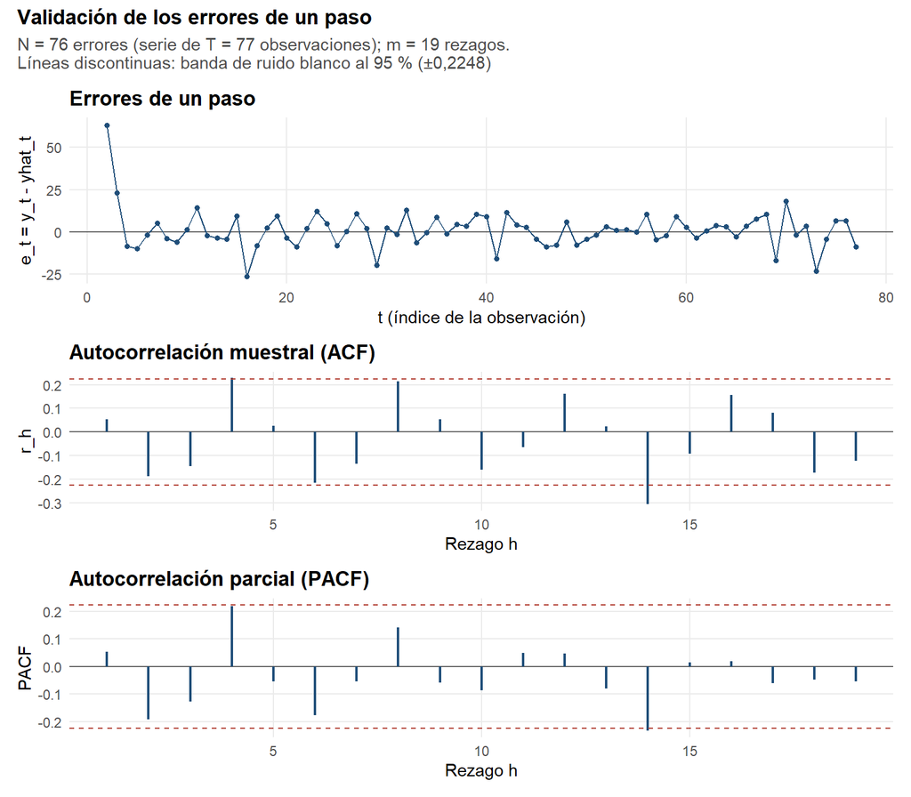

```r
cot <- .cotas("ej08", sum(!is.na(fit$errores)))
ve <- validar_errores(fit$errores, fit$n_param, T_est, cot$dL, cot$dU)
ve$grafico
```

Son $N = 76$ errores de un paso (solo el primer trimestre queda sin pronóstico), con $m = 19$ rezagos y banda de ±0,2248, calculada sobre $N$.

```r
pp(ve$t_media, paste0("El error medio es ", n4(mean(ve$e)), " sobre una desviación de ", n4(sd(ve$e)),
                      ": no se distingue de cero, así que Holt no sobrestima ni subestima en promedio dentro de la muestra."))
```

**Prueba t de media cero de los errores** (n = 76)

1. **Hipótesis.** $H_0:\ \mu_e = 0$; $H_1:\ \mu_e \neq 0$.
2. **Estadístico y distribución bajo $H_0$.** $t = \dfrac{\bar{e}}{s_e/\sqrt{N}}\ \overset{H_0}{\sim}\ t_{N-1}$; grados de libertad: $75$.
3. **Región de rechazo al 5 %.** $|t| > t_{0{,}975;\,75} = 1,9921$.
4. **Valor observado.** estadístico observado = 0,8151; valor p = 0,418.
5. **Decisión.** No se rechaza $H_0$ (nivel de significancia del 5 %).
6. **Lectura.** El error medio es 1,0656 sobre una desviación de 11,3975: no se distingue de cero, así que Holt no sobrestima ni subestima en promedio dentro de la muestra.

```r
pp(ve$ljung_box, paste0("Q = ", n4(ve$ljung_box$estadistico), " con ", ve$ljung_box$gl, " grados de libertad (m = ",
                        ve$correlograma$m, ", p = 2 porque se estimaron alpha y beta) y valor p ", pv(ve$ljung_box$valor_p),
                        ": se rechaza que los errores sean incorrelacionados. ", sum(abs(ve$correlograma$acf) > ve$correlograma$banda),
                        " de los ", ve$correlograma$m, " rezagos salen de la banda: r_4 = ", n4(ve$correlograma$acf[4]),
                        " y r_6 = ", n4(ve$correlograma$acf[6]), ", con r_2 = ", n4(ve$correlograma$acf[2]),
                        ". Es el mismo patrón alterno de período 4 que dejó la doble media móvil en el ejemplo 4."))
```

```r
pp(ve$jarque_bera, paste0("JB = ", n4(ve$jarque_bera$estadistico), " con asimetría ", n4(ve$jarque_bera$A), " y curtosis ",
                          n4(ve$jarque_bera$K), " (0 y 3 para una normal): se rechaza la normalidad por una cola derecha muy pesada. Como ",
                          "muestra el análisis de sensibilidad siguiente, la causa es un solo error, el primero."))
```

**Prueba de Jarque–Bera** (n = 76)

1. **Hipótesis.** $H_0:\ A = 0\ \text{y}\ K = 3$ (errores normales); $H_1:\ A \neq 0\ \text{o}\ K \neq 3$.
2. **Estadístico y distribución bajo $H_0$.** $JB = \dfrac{N}{6}\left[A^2 + \dfrac{(K-3)^2}{4}\right]\ \overset{H_0}{\sim}\ \chi^2_2$, con $A = m_3/m_2^{3/2}$ la asimetría y $K = m_4/m_2^2$ la curtosis muestrales; grados de libertad: $2$.
3. **Región de rechazo al 5 %.** $JB > \chi^2_{0{,}95;\,2} = 5,9915$.
4. **Valor observado.** estadístico observado = 385,9364; valor p < 0,001.
5. **Decisión.** Se rechaza $H_0$ (nivel de significancia del 5 %).
6. **Lectura.** JB = 385,9364 con asimetría 1,8451 y curtosis 13,4047 (0 y 3 para una normal): se rechaza la normalidad por una cola derecha muy pesada. Como muestra el análisis de sensibilidad siguiente, la causa es un solo error, el primero.

```r
pp(ve$durbin_watson, paste0("d = ", n4(ve$durbin_watson$estadistico), " queda por debajo de d_L = ", n2(cot$dL), " (N = ", ve$n,
                            ", k' = 1): la prueba rechaza la ausencia de autocorrelación positiva de orden uno, aunque r_1 = ",
                            n4(ve$correlograma$acf[1]), " es pequeño. Esa discrepancia también la produce el primer error, como se ve a continuación."))
```

**Prueba de Durbin–Watson** (n = 76)

1. **Hipótesis.** $H_0:\ \rho = 0$ (sin autocorrelación de orden 1); $H_1:\ \rho > 0$.
2. **Estadístico y distribución bajo $H_0$.** $d = \dfrac{\sum_{t=2}^{N}(e_t - e_{t-1})^2}{\sum_{t=1}^{N} e_t^2} \approx 2(1 - r_1)$; sin distribución exacta bajo $H_0$, se decide con las cotas $d_L$ y $d_U$.
3. **Región de rechazo al 5 %.** Se rechaza $H_0$ si $d < d_L = 1,6000$; no se rechaza si $d > d_U = 1,6500$; inconclusa si $d_L \le d \le d_U$.
4. **Valor observado.** estadístico observado = 1,4720; sin valor p exacto (se decide con las cotas tabuladas).
5. **Decisión.** Se rechaza $H_0$ (nivel de significancia del 5 %).
6. **Lectura.** d = 1,4720 queda por debajo de d_L = 1,60 (N = 76, k’ = 1): la prueba rechaza la ausencia de autocorrelación positiva de orden uno, aunque r_1 = 0,0543 es pequeño. Esa discrepancia también la produce el primer error, como se ve a continuación.

**Análisis de sensibilidad: el primer error.** Holt se inicializa con nivel $L_1 = Y_1$ y pendiente $\hat T_1 = 0$, de modo que el primer pronóstico es $\hat Y_2 = Y_1$ y su error es simplemente el crecimiento del primer trimestre. Ese error es un valor atípico de calentamiento:

```r
e_sin <- fit$errores; e_sin[2] <- NA              # se retira el primer error (el del calentamiento de la pendiente)
ve_sin <- validar_errores(e_sin, fit$n_param, T_est, cot$dL, cot$dU)
data.frame(Caso = c("Con los N errores", "Sin el primer error"),
           N = c(ve$n, ve_sin$n),
           `Primer error` = c(fit$errores[2], NA),
           `Jarque-Bera` = c(ve$jarque_bera$estadistico, ve_sin$jarque_bera$estadistico),
           `p de JB` = vapply(c(ve$jarque_bera$valor_p, ve_sin$jarque_bera$valor_p), pv, ""),
           `Durbin-Watson` = c(ve$durbin_watson$estadistico, ve_sin$durbin_watson$estadistico),
           `Ljung-Box` = c(ve$ljung_box$estadistico, ve_sin$ljung_box$estadistico),
           check.names = FALSE) |> tab()
```

| Caso | N | Primer error | Jarque-Bera | p de JB | Durbin-Watson | Ljung-Box |
| --- | --- | --- | --- | --- | --- | --- |
| Con los N errores | 76 | 63,2 | 385,9364 | < 0,001 | 1,4720 | 41,5037 |
| Sin el primer error | 75 | NA | 4,4544 | 0,108 | 2,2031 | 73,6809 |

El primer error vale 63,20, es decir, 7,12 desviaciones estándar de los demás. Al retirarlo, Jarque–Bera baja de 385,94 a 4,45 (valor p 0,108: ya no se rechaza) y Durbin–Watson sube de 1,4720 a 2,2031, que ya no rechaza (por encima de 2 se contrasta la alternativa negativa con $4 - d =$ 1,7969, mayor que $d_U =$ 1,65; las cotas de $N = 76$ se usan también para $N = 75$, porque con dos decimales coinciden). En cambio **Ljung–Box no depende de ese error**: sube de 41,50 a 73,68, porque el rezago 4 (0,4038 sin él) es real y no producto del calentamiento. La conclusión se separa en dos: los rechazos de normalidad y de Durbin–Watson son un efecto de la inicialización sobre un solo dato, y el de Ljung–Box refleja una estructura de período 4 que el método no modela.

## 10.7 Gráfico final

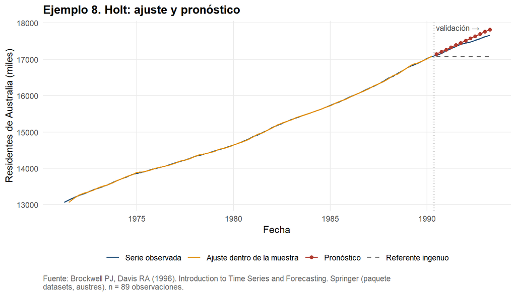

```r
.grafico_pronostico(d, fit$yhat, pron, ref, "Ejemplo 8. Holt: ajuste y pronóstico")
```

## 10.8 Conclusión

Se ajustó un Holt lineal con $\alpha =$ 0,95 y $\beta =$ 0,80, elegidos por `optimizar()` (MSE de un paso 129,3284, con $\alpha$ en el borde de la rejilla), sobre los 77 trimestres de estimación. Dentro de la muestra, a un paso, el MSE es 129,3284, el MAD 7,5298 y el MASE 0,1424 sobre 76 errores. En los 12 trimestres de validación el MSE es 8207,2350, el MAD 78,4718 y el MASE 1,4842, frente a 133004,7908, 322,0417 y 6,0912 del ingenuo: el método reduce el MSE del ingenuo en 93,83 % y el de la doble media móvil en 35,09 %. La validación de errores muestra error medio nulo (valor p 0,418) y un rechazo de Ljung–Box (valor p < 0,001) que se debe a una estructura de período 4; los rechazos de Jarque–Bera (valor p < 0,001) y de Durbin–Watson (1,4720 frente a $d_L =$ 1,60) desaparecen al retirar el primer error, que es del calentamiento.

## 10.9 Recomendación

El pronóstico le sirve a quien planee con la población de Australia con un horizonte de uno a cuatro trimestres, y mejora al de la doble media móvil. El límite es que sobrestima de forma sistemática: en los 12 trimestres de validación el error (observado menos pronóstico) fue negativo en 12 de 12, con 40,49 en $h = 1$ (0,24 % del valor observado) y 162,93 en $h = 12$ (0,92 %), unos 11,13 miles más por cada trimestre de horizonte. La pendiente con la que Holt extrapola (61,55 miles por trimestre al final de la estimación) fue mayor que la observada después (48,01), y como el error de una pendiente se acumula linealmente con el horizonte, más allá de un año el pronóstico ya no es fiable sin reestimar con cada dato nuevo.

# 11 Contraejemplo. Suavizamiento exponencial simple sobre `AirPassengers`

Los ocho ejemplos anteriores aplicaron cada método a una serie cuyo patrón corresponde a su supuesto. Este contraejemplo hace lo opuesto a propósito: ajusta un suavizamiento exponencial simple, pensado para un nivel local sin tendencia ni estacionalidad, a una serie que tiene las dos cosas. El objetivo no es que el método gane, sino mostrar con cifras en qué se nota que falla.

## 11.1 Descripción de la serie

```r
x <- AirPassengers
d <- leer_serie(x,
                fuente = "Box GEP, Jenkins GM, Reinsel GC (1994). Time Series Analysis: Forecasting and Control, 3rd ed. Prentice Hall (paquete datasets, AirPassengers)",
                unidad = "Pasajeros de aerolíneas internacionales (miles)")
s <- attr(d, "frecuencia")
descripcion(x, "AirPassengers", d)
```

| Campo | Valor |
| --- | --- |
| Nombre en R | AirPassengers |
| Fuente (help) | Box GEP, Jenkins GM, Reinsel GC (1994). Time Series Analysis: Forecasting and Control, 3rd ed. Prentice Hall (paquete datasets, AirPassengers) |
| Unidad | Pasajeros de aerolíneas internacionales (miles) |
| Frecuencia | 12 |
| Inicio (año, período) | 1949, 1 |
| Fin (año, período) | 1960, 12 |
| Rango de fechas | 1949-01-01 a 1960-12-01 |
| Observaciones | 144 |

## 11.2 Patrón de la serie

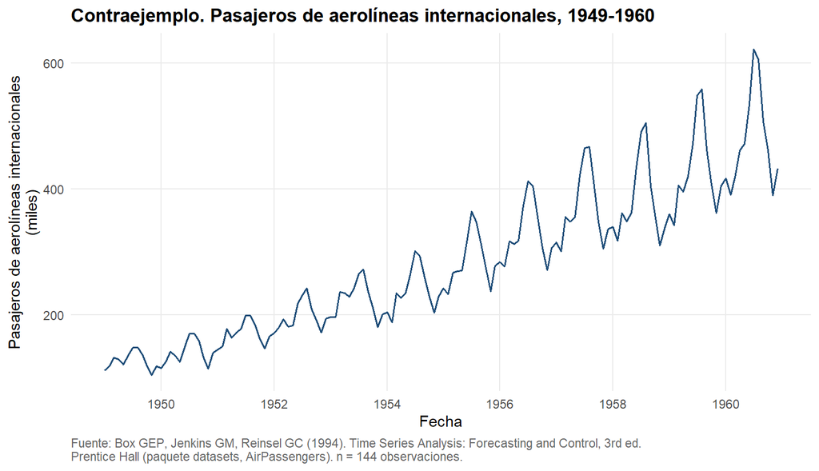

```r
graficar_serie(d, "Contraejemplo. Pasajeros de aerolíneas internacionales, 1949-1960")
```

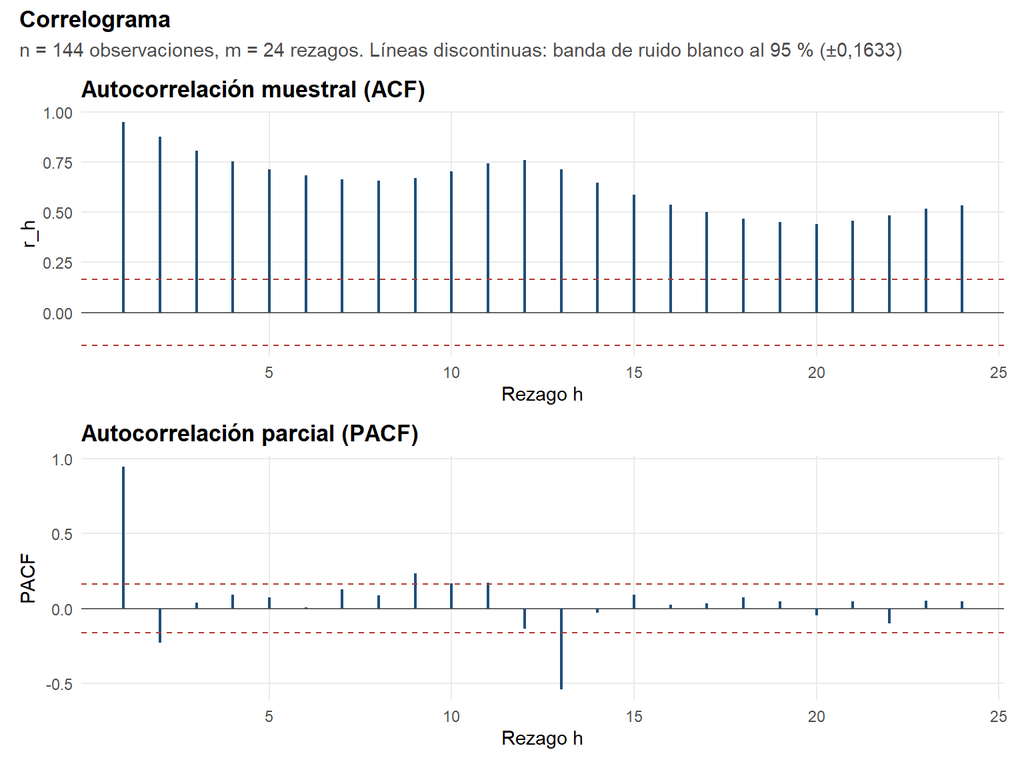

```r
cg <- correlograma(d)
cg$grafico
```

```r
n_total <- nrow(d)
r_1 <- .contraste_rh(cg$acf, n_total, 1)
pp(r_1, paste0("r_1 = ", n4(cg$acf[1]), " frente a una banda de ±", n4(cg$banda), ": la serie está lejos de ser ",
               "ruido blanco desde el primer rezago, lo mismo que en cualquier serie con tendencia."))
```

**Contraste individual de la autocorrelación en el rezago h = 1** (n = 144)

1. **Hipótesis.** $H_0:\ \rho_{1} = 0$; $H_1:\ \rho_{1} \neq 0$.
2. **Estadístico y distribución bajo $H_0$.** $T^* = \dfrac{r_h}{\sqrt{1/n}} = \sqrt{n}\, r_h\ \overset{H_0}{\approx}\ N(0,1)$.
3. **Región de rechazo al 5 %.** $|T^*| > z_{0{,}975} = 1,9600$, es decir $|r_{1}| > 0,1633$.
4. **Valor observado.** estadístico observado = 11,3766; valor p < 0,001.
5. **Decisión.** Se rechaza $H_0$ (nivel de significancia del 5 %).
6. **Lectura.** r_1 = 0,9480 frente a una banda de ±0,1633: la serie está lejos de ser ruido blanco desde el primer rezago, lo mismo que en cualquier serie con tendencia.

```r
r_12 <- .contraste_rh(cg$acf, n_total, s)
pp(r_12, paste0("r_", s, " = ", n4(cg$acf[s]), " también supera la banda: cada punto se parece al mismo mes del año ",
                "anterior. Es la firma de la estacionalidad, un patrón que ninguno de los ocho métodos de este trabajo modela."))
```

**Contraste individual de la autocorrelación en el rezago h = 12** (n = 144)

1. **Hipótesis.** $H_0:\ \rho_{12} = 0$; $H_1:\ \rho_{12} \neq 0$.
2. **Estadístico y distribución bajo $H_0$.** $T^* = \dfrac{r_h}{\sqrt{1/n}} = \sqrt{n}\, r_h\ \overset{H_0}{\approx}\ N(0,1)$.
3. **Región de rechazo al 5 %.** $|T^*| > z_{0{,}975} = 1,9600$, es decir $|r_{12}| > 0,1633$.
4. **Valor observado.** estadístico observado = 9,1247; valor p < 0,001.
5. **Decisión.** Se rechaza $H_0$ (nivel de significancia del 5 %).
6. **Lectura.** r_12 = 0,7604 también supera la banda: cada punto se parece al mismo mes del año anterior. Es la firma de la estacionalidad, un patrón que ninguno de los ocho métodos de este trabajo modela.

```r
lb0 <- ljung_box(cg$acf, n_total, cg$m, 0)
pp(lb0, paste0("Q = ", n4(lb0$estadistico), " con ", lb0$gl, " grados de libertad y valor p ", pv(lb0$valor_p),
               ": rechazo contundente, hay estructura de sobra para aprovechar y perder si el método no la modela."))
```

**Prueba de Ljung–Box** (n = 144)

1. **Hipótesis.** $H_0:\ \rho_1 = \rho_2 = \cdots = \rho_m = 0$; $H_1:\ \exists\, h \le m$ con $\rho_h \neq 0$.
2. **Estadístico y distribución bajo $H_0$.** $Q_m = T(T+2)\sum_{h=1}^{m} \dfrac{r_h^2}{T-h}\ \overset{H_0}{\sim}\ \chi^2_{m-p}$; $m = 24$, $p = 0$, luego los grados de libertad son $m - p = 24$.
3. **Región de rechazo al 5 %.** $Q_m > \chi^2_{0{,}95;\,24} = 36,4150$.
4. **Valor observado.** estadístico observado = 1606,0838; valor p < 0,001.
5. **Decisión.** Se rechaza $H_0$ (nivel de significancia del 5 %).
6. **Lectura.** Q = 1606,0838 con 24 grados de libertad y valor p < 0,001: rechazo contundente, hay estructura de sobra para aprovechar y perder si el método no la modela.

**Lectura del patrón.** La serie crece de forma sostenida (una regresión sobre $t$ explica el 85,36 % de la variación) y, sobre esa tendencia, repite un ciclo anual cuya amplitud crece con el nivel (más pasajeros en julio y agosto, menos a comienzos de año, y la diferencia entre esos meses es mayor al final de la serie que al principio). El supuesto de un suavizamiento exponencial simple es justo el opuesto: un nivel local sin tendencia, en el que Ŷ_{t+1} es un promedio ponderado de los datos pasados. Aquí ese promedio siempre queda por debajo en los meses de tendencia creciente y no tiene forma de anticipar el ciclo, porque solo tiene un parámetro (α) para dos patrones distintos que se le superponen.

## 11.3 Partición

```r
h <- min(12, floor(0.2 * n_total)); T_est <- n_total - h
est <- d[seq_len(T_est), ]; val <- d[T_est + seq_len(h), ]
```

Con $T = 144$ y $h = 12$ (un ciclo completo, $s = 12$), el tramo de estimación va de 1949-01 a 1959-12 ($T_{est} = 132$) y el de validación de 1960-01 a 1960-12.

## 11.4 Optimización de la constante

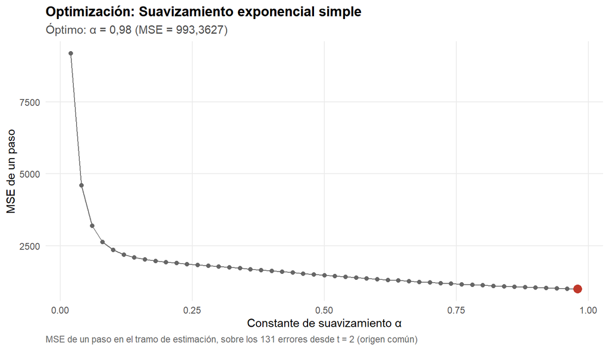

```r
opt <- optimizar(est$y, "ses")
opt$grafico
```

El óptimo es $\alpha =$ 0,98, en el borde superior de la rejilla (TRUE), con MSE 993,3627. Un $\alpha$ en el borde dice que conviene copiar casi por completo el último dato: el suavizamiento exponencial no encuentra ninguna mezcla interior que haga mejor trabajo que el ingenuo dentro de la muestra, porque ni el nivel puro ni ningún promedio ponderado de datos pasados sigue una serie que a la vez crece y oscila con el mes.

## 11.5 Ajuste y medidas

```r
fit <- ajustar_ses(est$y, opt$optimo$alpha)
pron <- fit$pronosticar(h)
ref <- rep(tail(est$y, s), length.out = h)          # ingenuo estacional: el último ciclo completo repetido
m_in <- .medir(est$y, fit$yhat, est$y, s)           # un paso, dentro del tramo de estimación
m_val <- .medir(val$y, pron, est$y, s)              # h pronósticos sobre el tramo de validación
m_ref <- .medir(val$y, ref, est$y, s)               # el ingenuo estacional, mismo tramo y mismo h
tab(.tabla_medidas(m_in, m_val, m_ref, "Ingenuo estacional"))
```

| caso | N | MSE | MAD | MAPE | MASE |
| --- | --- | --- | --- | --- | --- |
| Método, un paso (estimación) | 131 | 993,3627 | 24,2156 | 9,0252 | 0,7953 |
| Método, h pronósticos (validación) | 12 | 10724,6536 | 76,5610 | 14,3603 | 2,5143 |
| Ingenuo estacional, h pronósticos (validación) | 12 | 2571,3333 | 47,8333 | 9,9875 | 1,5709 |

Aquí es donde se ve la falla con números. El suavizamiento exponencial simple, que solo puede proyectar una línea plana, pierde contra el ingenuo estacional en las tres medidas de validación: MSE 10724,65 contra 2571,33 (317,09 % más alto), MAD 76,56 contra 47,83 y MASE 2,5143 contra 1,5709. Un MASE mayor que uno frente al ingenuo estacional significa que ni siquiera repetir el mismo mes del año anterior sin ajuste alguno es superado por el método: la línea plana ignora por completo el ciclo que el ingenuo estacional sí captura.

## 11.6 Validación de los errores de un paso

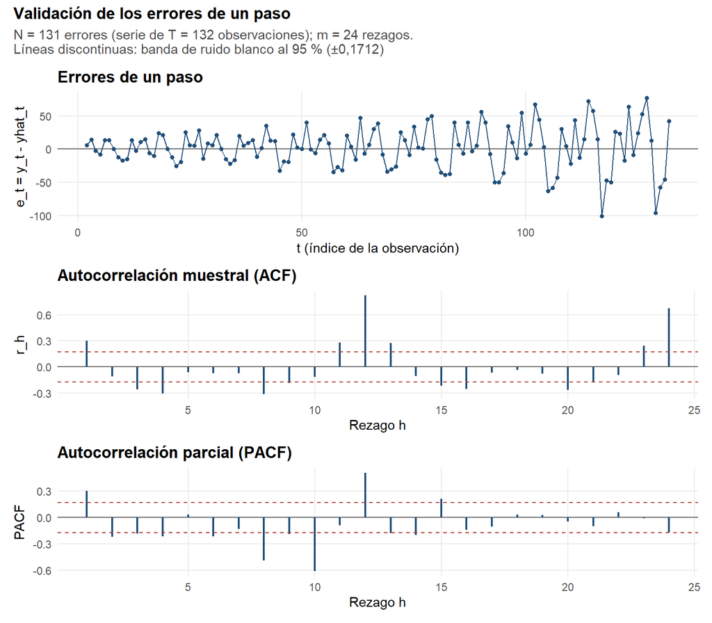

```r
cot <- .cotas("ej09", sum(!is.na(fit$errores)))
ve <- validar_errores(fit$errores, fit$n_param, T_est, cot$dL, cot$dU)
ve$grafico
```

Son $N = 131$ errores de un paso, con $m = 24$ rezagos y banda de ±0,1712, calculada sobre $N$.

```r
pp(ve$t_media, paste0("El error medio de un paso es ", n4(mean(ve$e)), " sobre una desviación de ", n4(sd(ve$e)),
                      ": no se distingue de cero, así que el sesgo del método no está en el nivel promedio sino en no ",
                      "seguir la forma del ciclo, que es lo que muestran las pruebas siguientes."))
```

**Prueba t de media cero de los errores** (n = 131)

1. **Hipótesis.** $H_0:\ \mu_e = 0$; $H_1:\ \mu_e \neq 0$.
2. **Estadístico y distribución bajo $H_0$.** $t = \dfrac{\bar{e}}{s_e/\sqrt{N}}\ \overset{H_0}{\sim}\ t_{N-1}$; grados de libertad: $130$.
3. **Región de rechazo al 5 %.** $|t| > t_{0{,}975;\,130} = 1,9784$.
4. **Valor observado.** estadístico observado = 0,8254; valor p = 0,411.
5. **Decisión.** No se rechaza $H_0$ (nivel de significancia del 5 %).
6. **Lectura.** El error medio de un paso es 2,2757 sobre una desviación de 31,5561: no se distingue de cero, así que el sesgo del método no está en el nivel promedio sino en no seguir la forma del ciclo, que es lo que muestran las pruebas siguientes.

```r
pp(ve$ljung_box, paste0("Q = ", n4(ve$ljung_box$estadistico), " con ", ve$ljung_box$gl, " grados de libertad (m = ",
                        ve$correlograma$m, ", p = 1 porque se estimó alpha) y valor p ", pv(ve$ljung_box$valor_p),
                        ": se rechaza con contundencia que los errores sean incorrelacionados. ",
                        sum(abs(ve$correlograma$acf) > ve$correlograma$banda), " de los ", ve$correlograma$m,
                        " rezagos salen de la banda, muy por encima del 5 % esperado por azar, y el más grande es ",
                        "justo r_", s, " = ", n4(ve$correlograma$acf[s]), ": los errores repiten el ciclo anual completo, ",
                        "porque el método nunca lo modeló."))
```

**Prueba de Ljung–Box sobre los errores** (n = 131)

1. **Hipótesis.** $H_0:\ \rho_1 = \rho_2 = \cdots = \rho_m = 0$; $H_1:\ \exists\, h \le m$ con $\rho_h \neq 0$.
2. **Estadístico y distribución bajo $H_0$.** $Q_m = T(T+2)\sum_{h=1}^{m} \dfrac{r_h^2}{T-h}\ \overset{H_0}{\sim}\ \chi^2_{m-p}$; $m = 24$, $p = 1$, luego los grados de libertad son $m - p = 23$.
3. **Región de rechazo al 5 %.** $Q_m > \chi^2_{0{,}95;\,23} = 35,1725$.
4. **Valor observado.** estadístico observado = 300,7176; valor p < 0,001.
5. **Decisión.** Se rechaza $H_0$ (nivel de significancia del 5 %).
6. **Lectura.** Q = 300,7176 con 23 grados de libertad (m = 24, p = 1 porque se estimó alpha) y valor p < 0,001: se rechaza con contundencia que los errores sean incorrelacionados. 13 de los 24 rezagos salen de la banda, muy por encima del 5 % esperado por azar, y el más grande es justo r_12 = 0,8231: los errores repiten el ciclo anual completo, porque el método nunca lo modeló.

```r
pp(ve$jarque_bera, paste0("JB = ", n4(ve$jarque_bera$estadistico), " con asimetría ", n4(ve$jarque_bera$A), " y curtosis ",
                          n4(ve$jarque_bera$K), " (0 y 3 para una normal) da valor p ", pv(ve$jarque_bera$valor_p),
                          ": no se rechaza la normalidad, porque la asimetría y la curtosis de los errores no se apartan ",
                          "mucho de las de una normal, aun cuando la prueba de Ljung-Box ya mostró que estos errores están lejos ",
                          "de ser independientes. Normalidad y ausencia de autocorrelación son dos supuestos distintos, y este caso ",
                          "muestra que uno puede fallar sin que el otro lo haga."))
```

**Prueba de Jarque–Bera** (n = 131)

1. **Hipótesis.** $H_0:\ A = 0\ \text{y}\ K = 3$ (errores normales); $H_1:\ A \neq 0\ \text{o}\ K \neq 3$.
2. **Estadístico y distribución bajo $H_0$.** $JB = \dfrac{N}{6}\left[A^2 + \dfrac{(K-3)^2}{4}\right]\ \overset{H_0}{\sim}\ \chi^2_2$, con $A = m_3/m_2^{3/2}$ la asimetría y $K = m_4/m_2^2$ la curtosis muestrales; grados de libertad: $2$.
3. **Región de rechazo al 5 %.** $JB > \chi^2_{0{,}95;\,2} = 5,9915$.
4. **Valor observado.** estadístico observado = 4,4196; valor p = 0,110.
5. **Decisión.** No se rechaza $H_0$ (nivel de significancia del 5 %).
6. **Lectura.** JB = 4,4196 con asimetría -0,3139 y curtosis 3,6446 (0 y 3 para una normal) da valor p 0,110: no se rechaza la normalidad, porque la asimetría y la curtosis de los errores no se apartan mucho de las de una normal, aun cuando la prueba de Ljung-Box ya mostró que estos errores están lejos de ser independientes. Normalidad y ausencia de autocorrelación son dos supuestos distintos, y este caso muestra que uno puede fallar sin que el otro lo haga.

```r
pp(ve$durbin_watson, paste0("d = ", n4(ve$durbin_watson$estadistico), " queda por debajo de d_L = ", n2(cot$dL), " (N = ", ve$n,
                            ", k' = 1): se rechaza la ausencia de autocorrelación positiva de orden uno, coherente con r_1 = ",
                            n4(ve$correlograma$acf[1]), ", aunque esa es apenas la punta de una estructura de período ", s,
                            " mucho más grande que Durbin-Watson, pensada para el rezago uno, no resume."))
```

**Prueba de Durbin–Watson** (n = 131)

1. **Hipótesis.** $H_0:\ \rho = 0$ (sin autocorrelación de orden 1); $H_1:\ \rho > 0$.
2. **Estadístico y distribución bajo $H_0$.** $d = \dfrac{\sum_{t=2}^{N}(e_t - e_{t-1})^2}{\sum_{t=1}^{N} e_t^2} \approx 2(1 - r_1)$; sin distribución exacta bajo $H_0$, se decide con las cotas $d_L$ y $d_U$.
3. **Región de rechazo al 5 %.** Se rechaza $H_0$ si $d < d_L = 1,7000$; no se rechaza si $d > d_U = 1,7300$; inconclusa si $d_L \le d \le d_U$.
4. **Valor observado.** estadístico observado = 1,3795; sin valor p exacto (se decide con las cotas tabuladas).
5. **Decisión.** Se rechaza $H_0$ (nivel de significancia del 5 %).
6. **Lectura.** d = 1,3795 queda por debajo de d_L = 1,70 (N = 131, k’ = 1): se rechaza la ausencia de autocorrelación positiva de orden uno, coherente con r_1 = 0,3005, aunque esa es apenas la punta de una estructura de período 12 mucho más grande que Durbin-Watson, pensada para el rezago uno, no resume.

## 11.7 Gráfico final

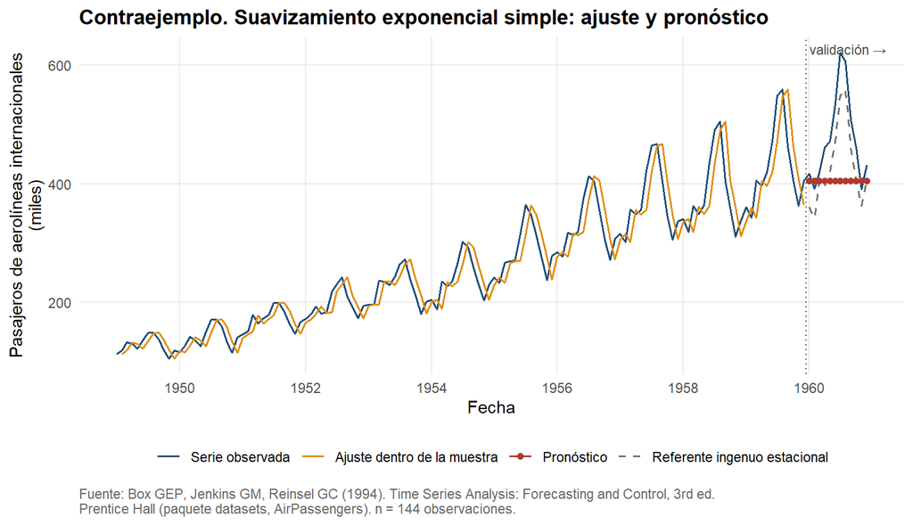

```r
.grafico_pronostico(d, fit$yhat, pron, ref, "Contraejemplo. Suavizamiento exponencial simple: ajuste y pronóstico",
                    nombre_referente = "Referente ingenuo estacional")
```

En el gráfico se ve la falla a simple vista: el ajuste dentro de muestra queda sistemáticamente por debajo del pico de cada julio-agosto y por encima del valle de cada comienzo de año, y el pronóstico de los 12 meses de validación es una línea prácticamente plana que no repite el ciclo que la propia serie de validación sí muestra.

## 11.8 Conclusión

Se ajustó un suavizamiento exponencial simple con $\alpha =$ 0,98, en el borde superior de la rejilla, sobre los 132 meses de estimación. En los 12 meses de validación el MASE es 2,5143, frente a 1,5709 del ingenuo estacional: el método **pierde** frente a un referente que se limita a repetir el ciclo anterior, algo que entre los ocho ejemplos previos solo ocurrió en el ejemplo 2, por un margen mínimo (ver la tabla resumen). La validación de errores confirma el mecanismo de la falla: el error medio es nulo (valor p 0,411), pero Ljung-Box rechaza con fuerza (valor p < 0,001) por una autocorrelación estacional en r_12 = 0,8231, muy por fuera de la banda de ±0,1712, y Durbin-Watson también rechaza (1,3795 frente a $d_L =$ 1,70). El único supuesto que no se rechaza es la normalidad (Jarque-Bera, valor p 0,110), lo que muestra que el problema del método aquí no es la forma de los errores sino su dependencia con el calendario, exactamente lo que el diagnóstico de la serie (r_12 = 0,7604 en la sección de patrón) ya anticipaba antes de ajustar nada.

## 11.9 Recomendación

Este método no le sirve a quien pronostique `AirPassengers`: pierde frente al ingenuo estacional en las tres medidas de validación y sus errores dejan un patrón de calendario que cualquier revisión mínima detecta. El límite no es de grado sino de especificación: ningún valor de α lo arregla, porque el problema no es la velocidad de reacción del nivel sino la ausencia de un término que module la tendencia y otro que module la estación. La lectura correcta de este contraejemplo no es “el suavizamiento exponencial simple es malo”, sino que cada uno de los ocho métodos de esta caja de herramientas debe aplicarse a una serie cuyo patrón corresponda a su supuesto, como se hizo en los ejemplos 1 a 8, y verificar ese supuesto con el gráfico y el correlograma antes de ajustar nada.

# 12 Tabla resumen

```r
resumen_df <- do.call(rbind, resumen)
supera <- resumen_df$MASE_metodo < resumen_df$MASE_referente
n_supera <- sum(supera)
tabla_resumen <- data.frame(Ejemplo = resumen_df$ejemplo, Serie = resumen_df$serie,
                            Método = resumen_df$metodo,
                            `MASE método` = resumen_df$MASE_metodo,
                            `MASE referente` = resumen_df$MASE_referente,
                            `Supera al referente` = ifelse(supera, "Sí", "No"),
                            check.names = FALSE)
tab(tabla_resumen)
```

| Ejemplo | Serie | Método | MASE método | MASE referente | Supera al referente |
| --- | --- | --- | --- | --- | --- |
| 1 | discoveries | Media simple | 0,9192 | 1,1365 | Sí |
| 2 | Nile | Media móvil (k = 2) | 0,8467 | 0,8355 | No |
| 3 | Nile | SES (alpha = 0.24) | 0,8062 | 0,8355 | Sí |
| 4 | austres | Doble media móvil (k = 2) | 1,8632 | 6,0912 | Sí |
| 5 | LakeHuron | Tendencia lineal | 2,0667 | 2,1642 | Sí |
| 6 | airmiles | Tendencia cuadratica | 1,2055 | 4,4959 | Sí |
| 7 | JohnsonJohnson | Tendencia exponencial | 3,5142 | 6,5286 | Sí |
| 8 | austres | Holt (alpha = 0.95, beta = 0.8) | 1,4842 | 6,0912 | Sí |
| C | AirPassengers | SES (alpha = 0.98) | 2,5143 | 1,5709 | No |

La tabla reúne el MASE de validación de cada método frente a su referente (el ingenuo, o el ingenuo estacional en `JohnsonJohnson` y `AirPassengers`), sobre el mismo tramo y el mismo horizonte $h$ declarados en cada ejemplo. De las 9 filas, 7 tienen un MASE del método menor que el de su referente; la que no lo tiene entre los ocho primeros es la media móvil del ejemplo 2, por un margen mínimo (0,8467 contra 0,8355), y se reportó así en su conclusión sin ocultarlo. El contraejemplo (fila C) es, a propósito, el caso donde el método pierde por el margen más amplio: 2,5143 contra 1,5709, la firma numérica de aplicar un suavizamiento sin tendencia ni estacionalidad a una serie que tiene las dos cosas.

# 13 Referencias

- Box GEP, Jenkins GM, Reinsel GC (1994). *Time Series Analysis: Forecasting and Control*, 3rd ed. Prentice Hall (fuente de `AirPassengers`).
- Brockwell PJ, Davis RA (1991). *Time Series: Theory and Methods*, 2nd ed. Springer (fuente de `LakeHuron`).
- Brockwell PJ, Davis RA (1996). *Introduction to Time Series and Forecasting*. Springer (fuente de `austres`).
- Durbin J, Koopman SJ (2001). *Time Series Analysis by State Space Methods*. Oxford University Press (fuente de `Nile`).
- Durbin J, Watson GS (1951). Testing for Serial Correlation in Least Squares Regression II. *Biometrika*, 38(1/2), 159-178.
- F.A.A. *Statistical Handbook of Aviation* (fuente de `airmiles`).
- Hyndman RJ, Koehler AB (2006). Another look at measures of forecast accuracy. *International Journal of Forecasting*, 22(4), 679-688 (definición del MASE).
- Imhof JP (1961). Computing the Distribution of Quadratic Forms in Normal Variables. *Biometrika*, 48(3/4), 419-426 (integral usada para las cotas exactas de Durbin-Watson).
- Ljung GM, Box GEP (1978). On a Measure of Lack of Fit in Time Series Models. *Biometrika*, 65(2), 297-303.
- Newey WK, West KD (1987). A Simple, Positive Semi-Definite, Heteroskedasticity and Autocorrelation Consistent Covariance Matrix. *Econometrica*, 55(3), 703-708.
- Savin NE, White KJ (1977). The Durbin-Watson Test for Serial Correlation with Extreme Sample Sizes or Many Regressors. *Econometrica*, 45(8), 1989-1996 (tabla de valores críticos de $d_L$ y $d_U$).
- Shumway RH, Stoffer DS (2000). *Time Series Analysis and its Applications*. Springer (fuente de `JohnsonJohnson`).
- The World Almanac and Book of Facts, 1975 Edition (fuente de `discoveries`).
- Notas de clase, Series de Tiempo (3009297), Universidad Nacional de Colombia, sede Medellín, 2026-II (definiciones, inicializaciones y demostraciones de las formas recursivas de los métodos).

# 14 Información de la sesión